# Lab 5

Madeleine Ashby

9/26/2021

# Dataset 1

Dataset = winequality-red-1

## Phase 1

Machine Learning Question: How can we predict the average quality of red wine?

Independent Business Metric: Assuming that higher quality results in higher sales, can we predict which new red wines that enter the market over the next year will perform the best?

## Phase 2

### Scale/Center/Normalizing

```r
#Read in dataset
wines <- read.csv("https://query.data.world/s/upbidgt5y4n6gudp3pl35uqcw7rr6x", header=TRUE, stringsAsFactors=FALSE)

str(wines)
```

```
## 'data.frame':    1599 obs. of  12 variables:
##  $ fixed_acidity       : num  7.4 7.8 7.8 11.2 7.4 7.4 7.9 7.3 7.8 7.5 ...
##  $ volatile_acidity    : num  0.7 0.88 0.76 0.28 0.7 0.66 0.6 0.65 0.58 0.5 ...
##  $ citric_acid         : num  0 0 0.04 0.56 0 0 0.06 0 0.02 0.36 ...
##  $ residual_sugar      : num  1.9 2.6 2.3 1.9 1.9 1.8 1.6 1.2 2 6.1 ...
##  $ chlorides           : num  0.076 0.098 0.092 0.075 0.076 0.075 0.069 0.065 0.073 0.071 ...
##  $ free_sulfur_dioxide : num  11 25 15 17 11 13 15 15 9 17 ...
##  $ total_sulfur_dioxide: num  34 67 54 60 34 40 59 21 18 102 ...
##  $ density             : num  0.998 0.997 0.997 0.998 0.998 ...
##  $ pH                  : num  3.51 3.2 3.26 3.16 3.51 3.51 3.3 3.39 3.36 3.35 ...
##  $ sulphates           : num  0.56 0.68 0.65 0.58 0.56 0.56 0.46 0.47 0.57 0.8 ...
##  $ alcohol             : num  9.4 9.8 9.8 9.8 9.4 9.4 9.4 10 9.5 10.5 ...
##  $ quality             : int  5 5 5 6 5 5 5 7 7 5 ...
```

```r
#we can see that all of the variables are numeric, so we just need to normalize using the min-max scaler function.

normalize <- function(x){
 (x - min(x)) / (max(x) - min(x))
}

numerics <- names(select_if(wines, is.numeric))
wines[numerics] <- as_tibble(lapply(wines[numerics], normalize))
str(wines)
```

```
## 'data.frame':    1599 obs. of  12 variables:
##  $ fixed_acidity       : num  0.248 0.283 0.283 0.584 0.248 ...
##  $ volatile_acidity    : num  0.397 0.521 0.438 0.11 0.397 ...
##  $ citric_acid         : num  0 0 0.04 0.56 0 0 0.06 0 0.02 0.36 ...
##  $ residual_sugar      : num  0.0685 0.1164 0.0959 0.0685 0.0685 ...
##  $ chlorides           : num  0.107 0.144 0.134 0.105 0.107 ...
##  $ free_sulfur_dioxide : num  0.141 0.338 0.197 0.225 0.141 ...
##  $ total_sulfur_dioxide: num  0.0989 0.2155 0.1696 0.1908 0.0989 ...
##  $ density             : num  0.568 0.494 0.509 0.582 0.568 ...
##  $ pH                  : num  0.606 0.362 0.409 0.331 0.606 ...
##  $ sulphates           : num  0.138 0.21 0.192 0.15 0.138 ...
##  $ alcohol             : num  0.154 0.215 0.215 0.215 0.154 ...
##  $ quality             : num  0.4 0.4 0.4 0.6 0.4 0.4 0.4 0.8 0.8 0.4 ...
```

```r
#now we can see the normalized values!  we do not need to one-hot encode for this dataset as there are no factor/character variables.
```

### Baseline/Prevalance

```r
describe(wines$quality)
```

```
##    vars    n mean   sd median trimmed mad min max range skew kurtosis se
## X1    1 1599 0.53 0.16    0.6    0.52 0.3   0   1     1 0.22     0.29  0
```

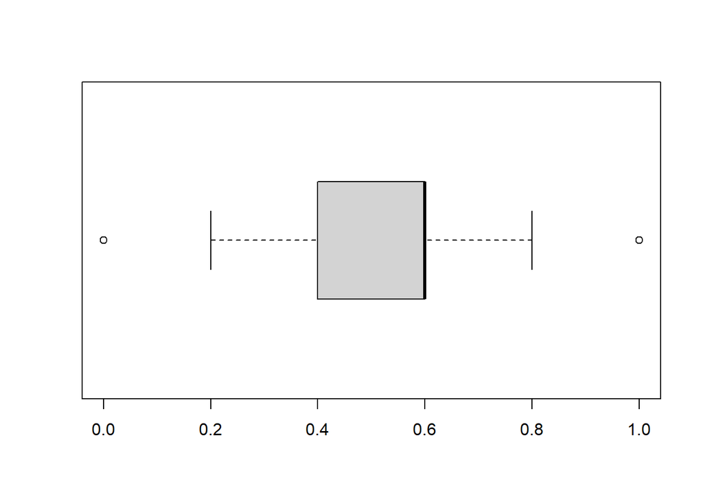

```
## $stats
##      [,1]
## [1,]  0.2
## [2,]  0.4
## [3,]  0.6
## [4,]  0.6
## [5,]  0.8
##
## $n
## [1] 1599
##
## $conf
##           [,1]
## [1,] 0.5920975
## [2,] 0.6079025
##
## $out
##  [1] 1 1 1 1 1 0 1 1 1 0 1 0 1 0 0 1 1 1 1 1 0 0 1 1 0 0 0 1
##
## $group
##  [1] 1 1 1 1 1 1 1 1 1 1 1 1 1 1 1 1 1 1 1 1 1 1 1 1 1 1 1 1
##
## $names
## [1] "1"
```

```r
(box <- boxplot(wines$quality, horizontal = TRUE))
```

```r
box$stats
```

```
##      [,1]
## [1,]  0.2
## [2,]  0.4
## [3,]  0.6
## [4,]  0.6
## [5,]  0.8
```

```r
fivenum(wines$quality)
```

```
## [1] 0.0 0.4 0.6 0.6 1.0
```

```r
#making a predictor!
(wines$quality_f <- cut(wines$quality,c(-1,.6,1),labels = c(0,1)))
```

```
##    [1] 0 0 0 0 0 0 0 1 1 0 0 0 0 0 0 0 1 0 0 0 0 0 0 0 0 0 0 0 0 0 0 0 0 0 0 0 0
##   [38] 1 0 0 0 0 0 0 0 0 0 0 0 0 0 0 0 0 0 0 0 0 0 0 0 0 1 0 0 0 0 0 0 0 0 0 0 0
##   [75] 0 0 0 0 0 0 0 0 0 0 0 0 0 0 0 0 0 0 0 0 0 0 0 0 0 0 0 0 0 0 0 0 0 0 0 0 0
##  [112] 0 0 0 0 0 0 0 0 0 0 0 0 0 0 0 0 0 1 0 0 0 0 0 0 0 0 0 0 0 0 0 0 0 0 0 0 0
##  [149] 0 0 0 0 0 0 0 0 0 0 0 0 0 0 0 0 0 0 0 0 0 0 0 0 0 0 0 0 0 0 0 0 0 0 0 0 0
##  [186] 0 0 0 0 0 0 0 0 0 0 0 0 0 1 0 1 0 0 0 0 1 1 0 0 1 0 0 0 0 0 0 0 0 0 0 0 0
##  [223] 0 0 0 0 0 0 0 0 1 0 0 0 0 0 0 0 0 0 0 0 0 1 1 0 0 0 0 0 0 0 0 0 0 0 0 0 0
##  [260] 1 0 0 0 0 0 1 0 1 0 0 0 0 0 0 0 0 0 0 1 1 0 1 0 1 0 0 0 0 1 0 1 0 0 0 0 0
##  [297] 0 0 0 0 0 0 0 0 0 0 0 0 0 0 0 0 0 0 0 0 0 0 1 0 1 0 0 0 0 0 1 0 0 0 0 0 0
##  [334] 0 1 1 0 0 0 1 0 0 0 0 0 0 1 0 0 0 0 0 0 0 0 0 0 1 1 0 0 0 0 0 1 0 1 0 0 1
##  [371] 0 0 0 0 0 1 0 1 0 0 0 0 0 0 0 0 0 0 0 1 1 0 0 0 0 1 0 0 0 0 0 0 0 0 0 0 0
##  [408] 1 0 0 0 0 0 1 0 0 0 0 0 0 1 1 0 1 0 1 0 0 0 0 1 0 0 0 0 0 0 0 0 0 1 0 1 1
##  [445] 1 0 0 0 0 0 0 0 0 1 0 1 0 0 1 0 0 0 0 0 0 0 0 0 0 0 0 0 0 0 0 0 0 0 0 0 0
##  [482] 1 0 0 0 0 0 0 1 0 0 1 1 0 0 1 0 0 1 0 0 1 1 1 1 1 1 0 0 1 0 0 0 1 1 0 0 0
##  [519] 0 0 0 0 0 0 0 0 0 0 0 0 0 0 0 0 0 0 0 0 1 0 0 0 0 0 0 0 0 0 0 0 0 0 0 0 0
```

[output cut: 30 more lines]

```r
(prevalence <- 1 - table(wines$quality_f)[[2]]/length(wines$quality_f))
```

```
## [1] 0.8642902
```

## Phase 3

### Initial Model Building: Decision Tree Style

```r
#data partitioning
#drop 'quality' column
wines <- wines[, -12]
str(wines)
```

```
## 'data.frame':    1599 obs. of  12 variables:
##  $ fixed_acidity       : num  0.248 0.283 0.283 0.584 0.248 ...
##  $ volatile_acidity    : num  0.397 0.521 0.438 0.11 0.397 ...
##  $ citric_acid         : num  0 0 0.04 0.56 0 0 0.06 0 0.02 0.36 ...
##  $ residual_sugar      : num  0.0685 0.1164 0.0959 0.0685 0.0685 ...
##  $ chlorides           : num  0.107 0.144 0.134 0.105 0.107 ...
##  $ free_sulfur_dioxide : num  0.141 0.338 0.197 0.225 0.141 ...
##  $ total_sulfur_dioxide: num  0.0989 0.2155 0.1696 0.1908 0.0989 ...
##  $ density             : num  0.568 0.494 0.509 0.582 0.568 ...
##  $ pH                  : num  0.606 0.362 0.409 0.331 0.606 ...
##  $ sulphates           : num  0.138 0.21 0.192 0.15 0.138 ...
##  $ alcohol             : num  0.154 0.215 0.215 0.215 0.154 ...
##  $ quality_f           : Factor w/ 2 levels "0","1": 1 1 1 1 1 1 1 2 2 1 ...
```

```r
part_index_1 <- caret::createDataPartition(wines$quality_f,
                                           times=1,
                                           p = 0.70,
                                           groups=1,
                                           list=FALSE)

train <- wines[part_index_1,]
tune_and_test <- wines[-part_index_1, ]

tune_and_test_index <- createDataPartition(tune_and_test$quality_f,
                                           p = .5,
                                           list = FALSE,
                                           times = 1)

tune <- tune_and_test[tune_and_test_index, ]
test <- tune_and_test[-tune_and_test_index, ]

dim(train)
```

```
## [1] 1120   12
```

```r
dim(tune)
```

```
## [1] 240  12
```

```r
dim(test)
```

```
## [1] 239  12
```

#### Cross Validation

```r
fitControl <- trainControl(method = "repeatedcv",
                          number = 10,
                          repeats = 5,
                          returnResamp="all")

# number - number of folds
# repeats - number of times the CV is repeated, here it's 5 take the average of
# those 5 repeats

# Choose the features and classes
```

#### Training & Evaluation

```r
features <- train[,-c(13)]
#target <- data.frame(as.numeric(as.character(train[,13])))
target <- data.frame(quality_f = train[,"quality_f"])

?train
```

```
## starting httpd help server ... done
```

```r
str(target)
```

```
## 'data.frame':    1120 obs. of  1 variable:
##  $ quality_f: Factor w/ 2 levels "0","1": 1 1 1 1 2 2 1 1 1 1 ...
```

```r
set.seed(1984)
wines_mdl <- train(x=features,
                y=target[,"quality_f"],
                trControl=fitControl,
                method="C5.0",
                verbose=TRUE)

wines_mdl
```

```
## C5.0
##
## 1120 samples
##   12 predictor
##    2 classes: '0', '1'
##
## No pre-processing
## Resampling: Cross-Validated (10 fold, repeated 5 times)
## Summary of sample sizes: 1007, 1009, 1007, 1009, 1008, 1008, ...
## Resampling results across tuning parameters:
##
##   model  winnow  trials  Accuracy  Kappa
##   rules  FALSE    1      1         1
##   rules  FALSE   10      1         1
##   rules  FALSE   20      1         1
##   rules   TRUE    1      1         1
##   rules   TRUE   10      1         1
##   rules   TRUE   20      1         1
##   tree   FALSE    1      1         1
##   tree   FALSE   10      1         1
##   tree   FALSE   20      1         1
##   tree    TRUE    1      1         1
##   tree    TRUE   10      1         1
##   tree    TRUE   20      1         1
##
## Accuracy was used to select the optimal model using the largest value.
## The final values used for the model were trials = 1, model = rules and winnow
##  = TRUE.
```

### Tune and Evaluation

```r
wines_predict = predict(wines_mdl,tune,type= "raw")

confusionMatrix(as.factor(wines_predict),
                as.factor(tune$quality_f),
                dnn=c("Prediction", "Actual"),
                mode = "sens_spec")
```

```
## Confusion Matrix and Statistics
##
##           Actual
## Prediction   0   1
##          0 207   0
##          1   0  33
##
##                Accuracy : 1
##                  95% CI : (0.9847, 1)
##     No Information Rate : 0.8625
##     P-Value [Acc > NIR] : 3.821e-16
##
##                   Kappa : 1
##
##  Mcnemar's Test P-Value : NA
##
##             Sensitivity : 1.0000
##             Specificity : 1.0000
##          Pos Pred Value : 1.0000
##          Neg Pred Value : 1.0000
##              Prevalence : 0.8625
##          Detection Rate : 0.8625
##    Detection Prevalence : 0.8625
##       Balanced Accuracy : 1.0000
##
##        'Positive' Class : 0
##
```

```r
varImp(wines_mdl)
```

```
## C5.0 variable importance
##
##                      Overall
## quality_f                100
## density                    0
## pH                         0
## total_sulfur_dioxide       0
## fixed_acidity              0
## volatile_acidity           0
## sulphates                  0
## chlorides                  0
## residual_sugar             0
## citric_acid                0
## free_sulfur_dioxide        0
## alcohol                    0
```

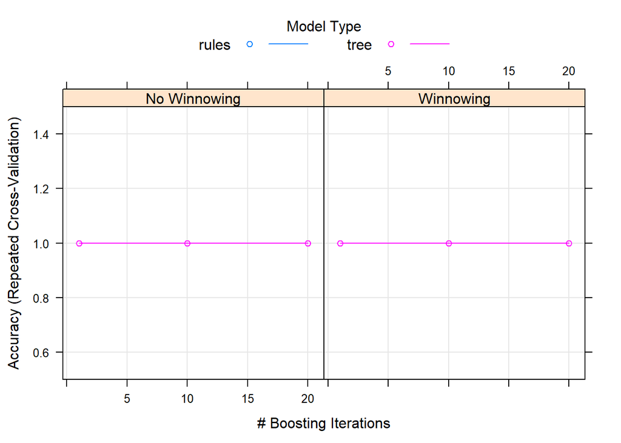

```r
plot(wines_mdl)
```

```r
grid <- expand.grid(.winnow = c(TRUE,FALSE),
                    .trials=c(20,30,40),
                    .model=c("tree","rules"))
set.seed(1984)
wines_mdl_tune <- train(x=features,
                y=target$quality_f,
                tuneGrid=grid,
                trControl=fitControl,
                method="C5.0",
                verbose=TRUE)

wines_mdl_tune
```

```
## C5.0
##
## 1120 samples
##   12 predictor
##    2 classes: '0', '1'
##
## No pre-processing
## Resampling: Cross-Validated (10 fold, repeated 5 times)
## Summary of sample sizes: 1007, 1009, 1007, 1009, 1008, 1008, ...
## Resampling results across tuning parameters:
##
##   model  winnow  trials  Accuracy  Kappa
##   rules  FALSE   20      1         1
##   rules  FALSE   30      1         1
##   rules  FALSE   40      1         1
##   rules   TRUE   20      1         1
##   rules   TRUE   30      1         1
##   rules   TRUE   40      1         1
##   tree   FALSE   20      1         1
##   tree   FALSE   30      1         1
##   tree   FALSE   40      1         1
##   tree    TRUE   20      1         1
##   tree    TRUE   30      1         1
##   tree    TRUE   40      1         1
##
## Accuracy was used to select the optimal model using the largest value.
## The final values used for the model were trials = 20, model = rules and
##  winnow = TRUE.
```

```r
wines_mdl
```

```
## C5.0
##
## 1120 samples
##   12 predictor
##    2 classes: '0', '1'
##
## No pre-processing
## Resampling: Cross-Validated (10 fold, repeated 5 times)
## Summary of sample sizes: 1007, 1009, 1007, 1009, 1008, 1008, ...
## Resampling results across tuning parameters:
##
##   model  winnow  trials  Accuracy  Kappa
##   rules  FALSE    1      1         1
##   rules  FALSE   10      1         1
##   rules  FALSE   20      1         1
##   rules   TRUE    1      1         1
##   rules   TRUE   10      1         1
##   rules   TRUE   20      1         1
##   tree   FALSE    1      1         1
##   tree   FALSE   10      1         1
##   tree   FALSE   20      1         1
##   tree    TRUE    1      1         1
##   tree    TRUE   10      1         1
##   tree    TRUE   20      1         1
##
## Accuracy was used to select the optimal model using the largest value.
## The final values used for the model were trials = 1, model = rules and winnow
##  = TRUE.
```

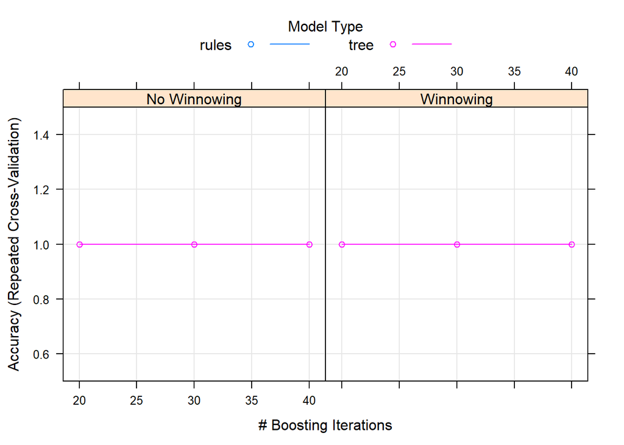

```r
plot(wines_mdl_tune)
```

```r
# Want to evaluation again with the tune data using the new model

wines_predict_tune = predict(wines_mdl_tune,tune,type= "raw")

confusionMatrix(as.factor(wines_predict_tune),
                as.factor(tune$quality_f),
                dnn=c("Prediction", "Actual"),
                mode = "sens_spec")
```

```
## Confusion Matrix and Statistics
##
##           Actual
## Prediction   0   1
##          0 207   0
##          1   0  33
##
##                Accuracy : 1
##                  95% CI : (0.9847, 1)
##     No Information Rate : 0.8625
##     P-Value [Acc > NIR] : 3.821e-16
##
##                   Kappa : 1
##
##  Mcnemar's Test P-Value : NA
##
##             Sensitivity : 1.0000
##             Specificity : 1.0000
##          Pos Pred Value : 1.0000
##          Neg Pred Value : 1.0000
##              Prevalence : 0.8625
##          Detection Rate : 0.8625
##    Detection Prevalence : 0.8625
##       Balanced Accuracy : 1.0000
##
##        'Positive' Class : 0
##
```

Explore variable importance measures: The varImp dataframe shows that the quality variable was found to reduce error and was included in each model created.

### Test

```r
wines_predict_test = predict(wines_mdl_tune,test,type= "raw")

confusionMatrix(as.factor(wines_predict_test),
                as.factor(test$quality_f),
                dnn=c("Prediction", "Actual"),
                mode = "sens_spec")
```

```
## Confusion Matrix and Statistics
##
##           Actual
## Prediction   0   1
##          0 207   0
##          1   0  32
##
##                Accuracy : 1
##                  95% CI : (0.9847, 1)
##     No Information Rate : 0.8661
##     P-Value [Acc > NIR] : 1.202e-15
##
##                   Kappa : 1
##
##  Mcnemar's Test P-Value : NA
##
##             Sensitivity : 1.0000
##             Specificity : 1.0000
##          Pos Pred Value : 1.0000
##          Neg Pred Value : 1.0000
##              Prevalence : 0.8661
##          Detection Rate : 0.8661
##    Detection Prevalence : 0.8661
##       Balanced Accuracy : 1.0000
##
##        'Positive' Class : 0
##
```

Evaluate using the confusion matrix function - did the model perform better or worse than the training version? The confusion matrix shows that the model performed about the same as the training version because they both had an accuracy of 1.

## Summary

Write a summary of your findings. What do you know now that you didn’t when you started? What items are you concerned about?

After exploring this dataset and using c5.0 to build models to train, tune, and evaluate, I found that this model was very accurate and thus useful in predicting the success of new wines that may be entering the market in the next year. However, I am a little concerned about this model because the accuracy right off the bat was 1, and this seems like there may not be enough data to actually train and test it thoroughly. Through debugging this code I learned about data partitioning and how the models are actually built using c5.0.

# Dataset 2

Dataset = netflix

## Phase 1

Machine Learning Question: How can we predict the user rating for a Netflix movie?

Independent Business Metric: Assuming that a higher user rating will affect the number of views a Netflix movie gets, can we predict which new Netflix movies that are produced over the next year will perform the best?

## Phase 2

### Scale/Center/Normalizing

```r
#Read in dataset
GET("https://query.data.world/s/os2idmbigqcekbj5hrw2fzf6m6epsj", write_disk(tf <- tempfile(fileext = ".xlsx")))
```

```
## Response [https://download.data.world/file_download/chasewillden/netflix-shows/netflix.xlsx?auth=eyJhbGciOiJIUzUxMiJ9.eyJzdWIiOiJwcm9kLXVzZXItY2xpZW50Om1hZGRpZWFzaGJ5IiwiaXNzIjoi….NplGZ_8dL42UpkZTj0PvvmMVIiOeZs-lxlmfd8abpxYi28nm3oLEDb8VwyyCHbPC4h7Rs5uJuOiOIEh6Mf_3Gg]
##   Date: 2021-10-04 20:04
##   Status: 200
##   Content-Type: application/vnd.openxmlformats-officedocument.spreadsheetml.sheet
##   Size: 117 kB
## <ON DISK>  C:\Users\Maddie\AppData\Local\Temp\Rtmp4sWYYB\file25c473456082.xlsx
```

```r
netflix <- read_excel(tf)

netflix[netflix == "NA" ] <- NA
netflix <- na.exclude(netflix)

str(netflix)
```

```
## tibble [574 x 7] (S3: tbl_df/tbl/data.frame)
##  $ title            : chr [1:574] "White Chicks" "Grey's Anatomy" "Prison Break" "How I Met Your Mother" ...
##  $ rating           : chr [1:574] "PG-13" "TV-14" "TV-14" "TV-PG" ...
##  $ ratingLevel      : chr [1:574] "crude and sexual humor, language and some drug content" "Parents strongly cautioned. May be unsuitable for children ages 14 and under." "Parents strongly cautioned. May be unsuitable for children ages 14 and under." "Parental guidance suggested. May not be suita…
##  $ ratingDescription: num [1:574] 80 90 90 70 90 110 90 110 90 70 ...
##  $ release year     : num [1:574] 2004 2016 2008 2014 2016 ...
##  $ user rating score: chr [1:574] "82" "98" "98" "94" ...
##  $ user rating size : num [1:574] 80 80 80 80 80 80 80 80 80 80 ...
##  - attr(*, "na.action")= 'exclude' Named int [1:426] 2 15 16 22 23 26 29 30 32 33 ...
##   ..- attr(*, "names")= chr [1:426] "2" "15" "16" "22" ...
```

```r
#drop columns we don't really need
netflix<-netflix[, -c(7)]
str(netflix)
```

```
## tibble [574 x 6] (S3: tbl_df/tbl/data.frame)
##  $ title            : chr [1:574] "White Chicks" "Grey's Anatomy" "Prison Break" "How I Met Your Mother" ...
##  $ rating           : chr [1:574] "PG-13" "TV-14" "TV-14" "TV-PG" ...
##  $ ratingLevel      : chr [1:574] "crude and sexual humor, language and some drug content" "Parents strongly cautioned. May be unsuitable for children ages 14 and under." "Parents strongly cautioned. May be unsuitable for children ages 14 and under." "Parental guidance suggested. May not be suita…
##  $ ratingDescription: num [1:574] 80 90 90 70 90 110 90 110 90 70 ...
##  $ release year     : num [1:574] 2004 2016 2008 2014 2016 ...
##  $ user rating score: chr [1:574] "82" "98" "98" "94" ...
##  - attr(*, "na.action")= 'exclude' Named int [1:426] 2 15 16 22 23 26 29 30 32 33 ...
##   ..- attr(*, "names")= chr [1:426] "2" "15" "16" "22" ...
```

```r
#fix variable types
netflix[,c(3)] <- lapply(netflix[,c(3)], as.factor)
netflix$`user rating score` <- as.numeric(netflix$`user rating score`)

#table(netflix$rating) #let's collapse this
netflix$rating <- fct_collapse(netflix$rating,
                           PG="PG", #New to Old
                           TV14="TV-14",
                           TVMA="TV-MA",
                           G="G",
                        other = c("NR","PG-13","R","TV-G","TV-PG",
                                  "TV-Y", "TV-Y7", "TV-Y7-FV")
                        )

#table(netflix$ratingLevel)
#Parents strongly cautioned. May be unsuitable for children ages 14 and under., For mature audiences.  May not be suitable for children 17 and under., General Audiences. Suitable for all ages., Suitable for all ages.

netflix$ratingLevel <- fct_collapse(netflix$ratingLevel,
                           ParentsCautioned="Parents strongly cautioned. May be unsuitable for children ages 14 and under.", #New to Old
                           Mature="For mature audiences.  May not be suitable for children 17 and under.",
                           SuitableAllAges="General Audiences. Suitable for all ages.",
                           SuitableAllAges="Suitable for all ages.",
                           group_other = TRUE
                        )
str(netflix)
```

```
## tibble [574 x 6] (S3: tbl_df/tbl/data.frame)
##  $ title            : chr [1:574] "White Chicks" "Grey's Anatomy" "Prison Break" "How I Met Your Mother" ...
##  $ rating           : Factor w/ 5 levels "G","other","PG",..: 2 4 4 2 4 5 4 5 4 2 ...
##  $ ratingLevel      : Factor w/ 4 levels "Mature","SuitableAllAges",..: 4 3 3 4 3 1 3 1 3 4 ...
##  $ ratingDescription: num [1:574] 80 90 90 70 90 110 90 110 90 70 ...
##  $ release year     : num [1:574] 2004 2016 2008 2014 2016 ...
##  $ user rating score: num [1:574] 82 98 98 94 95 97 91 98 96 98 ...
##  - attr(*, "na.action")= 'exclude' Named int [1:426] 2 15 16 22 23 26 29 30 32 33 ...
##   ..- attr(*, "names")= chr [1:426] "2" "15" "16" "22" ...
```

```r
#normalize
normalize <- function(x){
 (x - min(x)) / (max(x) - min(x))
}

netflix$`user rating score` <- normalize(netflix$`user rating score`)
netflix$ratingDescription <- normalize(netflix$ratingDescription)

str(netflix)
```

```
## tibble [574 x 6] (S3: tbl_df/tbl/data.frame)
##  $ title            : chr [1:574] "White Chicks" "Grey's Anatomy" "Prison Break" "How I Met Your Mother" ...
##  $ rating           : Factor w/ 5 levels "G","other","PG",..: 2 4 4 2 4 5 4 5 4 2 ...
##  $ ratingLevel      : Factor w/ 4 levels "Mature","SuitableAllAges",..: 4 3 3 4 3 1 3 1 3 4 ...
##  $ ratingDescription: num [1:574] 0.614 0.702 0.702 0.526 0.702 ...
##  $ release year     : num [1:574] 2004 2016 2008 2014 2016 ...
##  $ user rating score: num [1:574] 0.614 0.977 0.977 0.886 0.909 ...
##  - attr(*, "na.action")= 'exclude' Named int [1:426] 2 15 16 22 23 26 29 30 32 33 ...
##   ..- attr(*, "names")= chr [1:426] "2" "15" "16" "22" ...
```

```r
#now we can see the normalized values!
```

### One-hot encoding

```r
# Next let's one-hot encode those factor variables/character

#?one_hot

netflix_1h <- one_hot(as.data.table(netflix),cols = "auto",sparsifyNAs = TRUE,naCols = TRUE,dropCols = TRUE,dropUnusedLevels = TRUE)
describe(netflix_1h)
```

```
##                              vars   n    mean    sd  median trimmed   mad  min
## title*                          1 574  123.76 72.30  126.50  124.41 92.66    1
## rating_G                        2 574    0.09  0.29    0.00    0.00  0.00    0
## rating_other                    3 574    0.25  0.43    0.00    0.18  0.00    0
## rating_PG                       4 574    0.21  0.41    0.00    0.13  0.00    0
## rating_TV14                     5 574    0.32  0.47    0.00    0.28  0.00    0
## rating_TVMA                     6 574    0.13  0.34    0.00    0.04  0.00    0
## ratingLevel_Mature              7 574    0.13  0.34    0.00    0.04  0.00    0
## ratingLevel_SuitableAllAges     8 574    0.18  0.38    0.00    0.10  0.00    0
## ratingLevel_ParentsCautioned    9 574    0.32  0.47    0.00    0.27  0.00    0
## ratingLevel_Other              10 574    0.37  0.48    0.00    0.34  0.00    0
## ratingDescription              11 574    0.54  0.24    0.53    0.55  0.26    0
## release year                   12 574 2009.98  9.50 2015.00 2011.69  2.97 1940
## user rating score              13 574    0.66  0.28    0.75    0.69  0.27    0
##                               max range  skew kurtosis   se
## title*                        244   243 -0.06    -1.26 3.02
## rating_G                        1     1  2.81     5.90 0.01
## rating_other                    1     1  1.18    -0.61 0.02
## rating_PG                       1     1  1.44     0.07 0.02
## rating_TV14                     1     1  0.77    -1.41 0.02
## rating_TVMA                     1     1  2.14     2.59 0.01
## ratingLevel_Mature              1     1  2.14     2.59 0.01
## ratingLevel_SuitableAllAges     1     1  1.68     0.83 0.02
## ratingLevel_ParentsCautioned    1     1  0.78    -1.40 0.02
## ratingLevel_Other               1     1  0.54    -1.71 0.02
## ratingDescription               1     1 -0.40    -0.73 0.01
## release year                 2017    77 -2.88    14.49 0.40
## user rating score               1     1 -0.71    -0.67 0.01
```

```r
str(netflix_1h)
```

```
## Classes 'data.table' and 'data.frame':   574 obs. of  13 variables:
##  $ title                       : chr  "White Chicks" "Grey's Anatomy" "Prison Break" "How I Met Your Mother" ...
##  $ rating_G                    : int  0 0 0 0 0 0 0 0 0 0 ...
##  $ rating_other                : int  1 0 0 1 0 0 0 0 0 1 ...
##  $ rating_PG                   : int  0 0 0 0 0 0 0 0 0 0 ...
##  $ rating_TV14                 : int  0 1 1 0 1 0 1 0 1 0 ...
##  $ rating_TVMA                 : int  0 0 0 0 0 1 0 1 0 0 ...
##  $ ratingLevel_Mature          : int  0 0 0 0 0 1 0 1 0 0 ...
##  $ ratingLevel_SuitableAllAges : int  0 0 0 0 0 0 0 0 0 0 ...
##  $ ratingLevel_ParentsCautioned: int  0 1 1 0 1 0 1 0 1 0 ...
##  $ ratingLevel_Other           : int  1 0 0 1 0 0 0 0 0 1 ...
##  $ ratingDescription           : num  0.614 0.702 0.702 0.526 0.702 ...
##  $ release year                : num  2004 2016 2008 2014 2016 ...
##  $ user rating score           : num  0.614 0.977 0.977 0.886 0.909 ...
##  - attr(*, ".internal.selfref")=<externalptr>
```

### Baseline/Prevalance

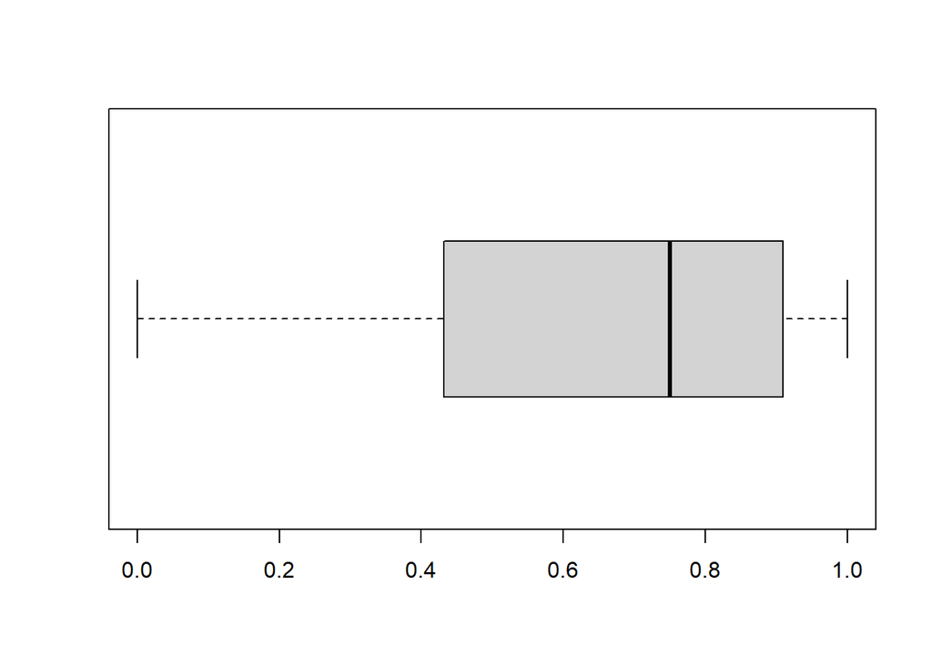

```
## $stats
##           [,1]
## [1,] 0.0000000
## [2,] 0.4318182
## [3,] 0.7500000
## [4,] 0.9090909
## [5,] 1.0000000
##
## $n
## [1] 574
##
## $conf
##           [,1]
## [1,] 0.7185249
## [2,] 0.7814751
##
## $out
## numeric(0)
##
## $group
## numeric(0)
##
## $names
## [1] "1"
```

```r
#describe(netflix_1h$`user rating score`)

(box <- boxplot(netflix_1h$`user rating score`, horizontal = TRUE))
```

```r
box$stats
```

```
##           [,1]
## [1,] 0.0000000
## [2,] 0.4318182
## [3,] 0.7500000
## [4,] 0.9090909
## [5,] 1.0000000
```

```r
fivenum(netflix_1h$`user rating score`)
```

```
## [1] 0.0000000 0.4318182 0.7500000 0.9090909 1.0000000
```

```r
#making a predictor!
(netflix_1h$`user rating score` <- cut(netflix_1h$`user rating score`,c(-1,.909,1),labels = c(0,1)))
```

```
##   [1] 0 1 1 0 1 1 0 1 1 1 1 0 0 1 0 0 1 0 0 1 0 1 0 0 0 1 1 1 1 0 1 0 1 1 0 0 0
##  [38] 1 1 1 0 0 1 1 1 0 0 1 0 0 1 0 1 0 1 0 1 0 1 0 0 0 1 0 1 0 0 0 0 0 1 1 0 0
##  [75] 0 0 1 0 0 0 0 0 1 0 0 0 0 0 1 0 0 0 0 0 0 0 0 0 0 0 0 1 0 1 0 0 0 0 0 0 0
## [112] 0 0 0 0 0 0 0 0 0 0 0 0 0 0 0 0 0 1 0 0 0 0 0 0 0 0 0 0 1 0 1 0 1 1 0 1 0
## [149] 0 0 1 1 1 0 0 0 0 0 1 1 0 0 0 0 0 0 0 0 0 1 0 1 0 1 0 0 0 0 0 0 0 0 0 1 1
## [186] 1 1 0 1 1 0 1 0 0 0 1 1 0 0 0 0 0 0 1 1 0 0 0 0 0 1 0 0 0 0 1 1 1 0 0 1 1
## [223] 0 1 0 1 1 0 0 0 0 0 0 0 1 0 1 0 1 0 0 0 1 0 0 0 1 0 1 0 0 1 0 0 0 0 1 0 1
## [260] 1 0 1 0 1 1 0 1 1 0 0 1 0 1 0 0 0 0 1 0 0 1 0 0 0 0 0 1 0 1 1 0 0 0 0 0 0
## [297] 1 1 1 0 1 0 1 0 0 0 1 1 0 0 0 1 0 1 0 1 0 0 0 1 0 0 1 0 1 0 0 0 1 0 0 0 0
## [334] 0 0 0 0 1 0 0 0 0 0 0 1 0 0 0 0 0 0 0 0 0 1 0 0 0 0 0 0 0 0 0 0 0 0 0 0 0
## [371] 0 0 0 0 0 0 1 1 0 1 0 0 0 0 0 1 0 0 0 0 0 0 0 0 0 0 0 0 0 0 1 1 0 0 1 1 0
## [408] 0 0 0 1 0 0 1 1 0 0 0 0 0 0 0 0 0 0 0 0 0 0 0 0 0 0 1 0 0 0 0 1 1 0 0 1 0
## [445] 0 0 1 0 0 1 1 0 1 0 0 0 0 0 1 0 0 0 0 0 0 0 0 0 0 1 0 0 0 0 0 0 1 1 0 0 1
## [482] 1 0 1 0 0 0 0 0 0 1 0 0 1 0 0 0 0 0 0 0 0 0 1 0 0 0 0 0 0 0 0 0 0 0 0 0 0
## [519] 0 0 1 0 0 1 0 0 0 0 0 0 0 0 0 1 0 0 1 0 0 0 0 0 1 0 0 0 0 0 0 0 0 0 0 0 0
## [556] 0 0 0 0 0 0 0 0 0 0 0 0 0 0 0 0 0 0 1
## Levels: 0 1
```

```r
(prevalence <- 1 - table(netflix_1h$`user rating score`)[[2]]/length(netflix_1h$`user rating score`))
```

```
## [1] 0.7421603
```

## Phase 3

### Initial Model Building: Decision Tree Style

```r
#drop cols 1 & 11
netflix_1h <- netflix_1h[, -c(1,11)]

#data partitioning
part_index_1 <- caret::createDataPartition(netflix_1h$`user rating score`,
                                           times=1,
                                           p = 0.70,
                                           groups=1,
                                           list=FALSE
                                           )
#help(createDataPartition)
train <- netflix_1h[part_index_1,]
tune_and_test <- netflix_1h[-part_index_1, ]

tune_and_test_index <- createDataPartition(tune_and_test$`user rating score`,
                                           p = .5,
                                           list = FALSE,
                                           times = 1)

tune <- tune_and_test[tune_and_test_index, ]
test <- tune_and_test[-tune_and_test_index, ]

dim(train)
```

```
## [1] 403  11
```

```r
dim(tune)
```

```
## [1] 86 11
```

```r
dim(test)
```

```
## [1] 85 11
```

#### Cross Validation

```r
fitControl <- trainControl(method = "repeatedcv",
                          number = 10,
                          repeats = 5,
                          returnResamp="all")

# number - number of folds
# repeats - number of times the CV is repeated, here it's 5 take the average of
# those 5 repeats

# Choose the features and classes
```

#### Training & Evaluation

```r
features <- train[,-c(11)]
#target <- train[, "user rating score"]
target <- data.frame(`user rating score` = train[,11])

set.seed(1984)
netflix_mdl <- train(x=features,
                y=target[,"user.rating.score"],
                trControl=fitControl,
                method="C5.0",
                verbose=TRUE)

netflix_mdl
```

```
## C5.0
##
## 403 samples
##  10 predictor
##   2 classes: '0', '1'
##
## No pre-processing
## Resampling: Cross-Validated (10 fold, repeated 5 times)
## Summary of sample sizes: 363, 363, 362, 363, 363, 363, ...
## Resampling results across tuning parameters:
##
##   model  winnow  trials  Accuracy   Kappa
##   rules  FALSE    1      0.7524572  0.15608645
##   rules  FALSE   10      0.7648365  0.25670403
##   rules  FALSE   20      0.7628609  0.25421344
##   rules   TRUE    1      0.7364694  0.06978244
##   rules   TRUE   10      0.7523974  0.19748022
##   rules   TRUE   20      0.7498974  0.20060698
##   tree   FALSE    1      0.7742755  0.28353085
##   tree   FALSE   10      0.7712992  0.27228810
##   tree   FALSE   20      0.7703114  0.27398949
##   tree    TRUE    1      0.7598730  0.17619277
##   tree    TRUE   10      0.7558487  0.18424414
##   tree    TRUE   20      0.7558487  0.18424414
##
## Accuracy was used to select the optimal model using the largest value.
## The final values used for the model were trials = 1, model = tree and winnow
##  = FALSE.
```

### Tune and Evaluation

```r
netflix_predict = predict(netflix_mdl,tune,type= "raw")

confusionMatrix(as.factor(netflix_predict),
                as.factor(tune$`user rating score`),
                dnn=c("Prediction", "Actual"),
                mode = "sens_spec")
```

```
## Confusion Matrix and Statistics
##
##           Actual
## Prediction  0  1
##          0 58 17
##          1  6  5
##
##                Accuracy : 0.7326
##                  95% CI : (0.6262, 0.8223)
##     No Information Rate : 0.7442
##     P-Value [Acc > NIR] : 0.65091
##
##                   Kappa : 0.1597
##
##  Mcnemar's Test P-Value : 0.03706
##
##             Sensitivity : 0.9062
##             Specificity : 0.2273
##          Pos Pred Value : 0.7733
##          Neg Pred Value : 0.4545
##              Prevalence : 0.7442
##          Detection Rate : 0.6744
##    Detection Prevalence : 0.8721
##       Balanced Accuracy : 0.5668
##
##        'Positive' Class : 0
##
```

```r
varImp(netflix_mdl)
```

```
## C5.0 variable importance
##
##                              Overall
## rating_other                  100.00
## releaseyear                    75.68
## rating_TVMA                    65.51
## rating_PG                      22.08
## rating_TV14                    19.60
## rating_G                        0.00
## ratingLevel_Mature              0.00
## ratingLevel_Other               0.00
## ratingLevel_ParentsCautioned    0.00
## ratingLevel_SuitableAllAges     0.00
## release year                    0.00
```

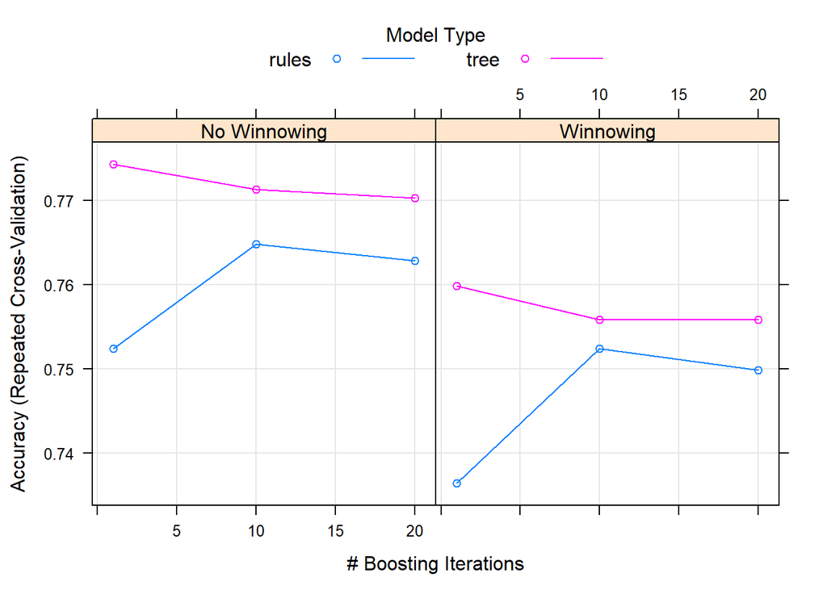

```r
plot(netflix_mdl)
```

```r
grid <- expand.grid(.winnow = c(TRUE,FALSE),
                    .trials=c(20,30,40),
                    .model=c("tree","rules"))
set.seed(1984)
netflix_mdl_tune <- train(x=features,
                y=target$user.rating.score,
                tuneGrid=grid,
                trControl=fitControl,
                method="C5.0",
                verbose=TRUE)

netflix_mdl_tune
```

```
## C5.0
##
## 403 samples
##  10 predictor
##   2 classes: '0', '1'
##
## No pre-processing
## Resampling: Cross-Validated (10 fold, repeated 5 times)
## Summary of sample sizes: 363, 363, 362, 363, 363, 363, ...
## Resampling results across tuning parameters:
##
##   model  winnow  trials  Accuracy   Kappa
##   rules  FALSE   20      0.7638609  0.2559248
##   rules  FALSE   30      0.7638609  0.2559248
##   rules  FALSE   40      0.7638609  0.2559248
##   rules   TRUE   20      0.7503974  0.1986194
##   rules   TRUE   30      0.7503974  0.1986194
##   rules   TRUE   40      0.7503974  0.1986194
##   tree   FALSE   20      0.7703114  0.2739895
##   tree   FALSE   30      0.7703114  0.2739895
##   tree   FALSE   40      0.7703114  0.2739895
##   tree    TRUE   20      0.7558487  0.1842441
##   tree    TRUE   30      0.7558487  0.1842441
##   tree    TRUE   40      0.7558487  0.1842441
##
## Accuracy was used to select the optimal model using the largest value.
## The final values used for the model were trials = 20, model = tree and winnow
##  = FALSE.
```

```r
netflix_mdl
```

```
## C5.0
##
## 403 samples
##  10 predictor
##   2 classes: '0', '1'
##
## No pre-processing
## Resampling: Cross-Validated (10 fold, repeated 5 times)
## Summary of sample sizes: 363, 363, 362, 363, 363, 363, ...
## Resampling results across tuning parameters:
##
##   model  winnow  trials  Accuracy   Kappa
##   rules  FALSE    1      0.7524572  0.15608645
##   rules  FALSE   10      0.7648365  0.25670403
##   rules  FALSE   20      0.7628609  0.25421344
##   rules   TRUE    1      0.7364694  0.06978244
##   rules   TRUE   10      0.7523974  0.19748022
##   rules   TRUE   20      0.7498974  0.20060698
##   tree   FALSE    1      0.7742755  0.28353085
##   tree   FALSE   10      0.7712992  0.27228810
##   tree   FALSE   20      0.7703114  0.27398949
##   tree    TRUE    1      0.7598730  0.17619277
##   tree    TRUE   10      0.7558487  0.18424414
##   tree    TRUE   20      0.7558487  0.18424414
##
## Accuracy was used to select the optimal model using the largest value.
## The final values used for the model were trials = 1, model = tree and winnow
##  = FALSE.
```

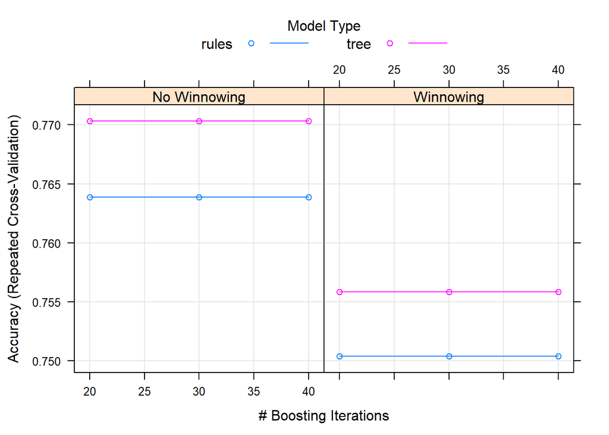

```r
plot(netflix_mdl_tune)
```

```r
# Want to evaluation again with the tune data using the new model

netflix_predict_tune = predict(netflix_mdl_tune,tune,type= "raw")

confusionMatrix(as.factor(netflix_predict_tune),
                as.factor(tune$`user rating score`),
                dnn=c("Prediction", "Actual"),
                mode = "sens_spec")
```

```
## Confusion Matrix and Statistics
##
##           Actual
## Prediction  0  1
##          0 58 15
##          1  6  7
##
##                Accuracy : 0.7558
##                  95% CI : (0.6513, 0.842)
##     No Information Rate : 0.7442
##     P-Value [Acc > NIR] : 0.45880
##
##                   Kappa : 0.2592
##
##  Mcnemar's Test P-Value : 0.08086
##
##             Sensitivity : 0.9062
##             Specificity : 0.3182
##          Pos Pred Value : 0.7945
##          Neg Pred Value : 0.5385
##              Prevalence : 0.7442
##          Detection Rate : 0.6744
##    Detection Prevalence : 0.8488
##       Balanced Accuracy : 0.6122
##
##        'Positive' Class : 0
##
```

### Test

```r
netflix_predict_test = predict(netflix_mdl_tune,test,type= "raw")

confusionMatrix(as.factor(netflix_predict_test),
                as.factor(test$`user rating score`),
                dnn=c("Prediction", "Actual"),
                mode = "sens_spec")
```

```
## Confusion Matrix and Statistics
##
##           Actual
## Prediction  0  1
##          0 58 16
##          1  5  6
##
##                Accuracy : 0.7529
##                  95% CI : (0.6475, 0.8401)
##     No Information Rate : 0.7412
##     P-Value [Acc > NIR] : 0.4586
##
##                   Kappa : 0.2309
##
##  Mcnemar's Test P-Value : 0.0291
##
##             Sensitivity : 0.9206
##             Specificity : 0.2727
##          Pos Pred Value : 0.7838
##          Neg Pred Value : 0.5455
##              Prevalence : 0.7412
##          Detection Rate : 0.6824
##    Detection Prevalence : 0.8706
##       Balanced Accuracy : 0.5967
##
##        'Positive' Class : 0
##
```

## Summary

# Dataset 3

Dataset = ramen

## Phase 1

Machine Learning Question: How can we predict how well-liked a ramen will be?

Independent Business Metric: Assuming that higher rating results in higher sales, can we predict which new Ramens that enter the market over the next year will perform the best?

## Phase 2

### Scale/Center/Normalizing

```r
#Read in dataset
GET("https://query.data.world/s/q6uw5pouwzvhm3smmkrxihp7xulhzx", write_disk(tf <- tempfile(fileext = ".xlsx")))
```

```
## Response [https://download.data.world/file_download/ian/ramen-ratings/The%20Ramen%20Rater%20-%20The%20Big%20List_Corrected.xlsx?auth=eyJhbGciOiJIUzUxMiJ9.eyJzdWIiOiJwcm9kLXVzZXItY2xpZW50Om1hZGRpZWFzaGJ5IiwiaXNzIjoi….EkTPbQnZBrJtrUZ4AGdkEbhD4G7wCbMQHb2tBRupZGPt1Fg8JkI4safs06vVQJ7p6HPwrWVtidc2k_5p2…
##   Date: 2021-10-04 20:04
##   Status: 200
##   Content-Type: application/vnd.openxmlformats-officedocument.spreadsheetml.sheet
##   Size: 152 kB
## <ON DISK>  C:\Users\Maddie\AppData\Local\Temp\Rtmp4sWYYB\file25c43ab360ac.xlsx
```

```r
ramen <- read_excel(tf)

#column "TopTen" doesn't have any values, so we can just drop the column.
ramen <- ramen[, -(7)]
ramen[ramen == "NR" ] <- NA
ramen[ramen == "Unrated"] <- NA
ramen <- na.exclude(ramen)
str(ramen)
```

```
## tibble [2,744 x 6] (S3: tbl_df/tbl/data.frame)
##  $ Review #: num [1:2744] 2750 2749 2748 2747 2746 ...
##  $ Brand   : chr [1:2744] "Nissin" "Maruchan" "MyKuali" "Nissin" ...
##  $ Variety : chr [1:2744] "Cup Noodles Tom Yum Goong Flavour Potato Chips" "Bariuma Goboten Udon" "Penang Red Tom Yum Goong Noodle (2018 Recipe)" "Cup Noodles Kyushu White Flavour (Open Sesame)" ...
##  $ Style   : chr [1:2744] "Pack" "Bowl" "Pack" "Cup" ...
##  $ Country : chr [1:2744] "Hong Kong" "Japan" "Malaysia" "Singapore" ...
##  $ Stars   : chr [1:2744] "5" "0" "5" "3.5" ...
##  - attr(*, "na.action")= 'exclude' Named int [1:6] 110 203 293 1164 2323 2613
##   ..- attr(*, "names")= chr [1:6] "110" "203" "293" "1164" ...
```

```r
#table(ramen$Brand)
# collapse Brand into Maruchan, Nissin, Nongshim, other

ramen$Brand <- fct_collapse(ramen$Brand,
                           Maruchan="Maruchan", #New to Old
                           Nissin="Nissin",
                           Nongshim="Nongshim",
                           group_other = TRUE
)

#change variables to be correct type
ramen[,c(4)] <- lapply(ramen[,c(4)], as.factor)
ramen$Stars <- as.numeric(ramen$Stars)

str(ramen)
```

```
## tibble [2,744 x 6] (S3: tbl_df/tbl/data.frame)
##  $ Review #: num [1:2744] 2750 2749 2748 2747 2746 ...
##  $ Brand   : Factor w/ 4 levels "Maruchan","Nissin",..: 2 1 4 2 4 2 4 3 4 4 ...
##  $ Variety : chr [1:2744] "Cup Noodles Tom Yum Goong Flavour Potato Chips" "Bariuma Goboten Udon" "Penang Red Tom Yum Goong Noodle (2018 Recipe)" "Cup Noodles Kyushu White Flavour (Open Sesame)" ...
##  $ Style   : Factor w/ 8 levels "Bar","Bowl","Box",..: 6 2 6 5 6 8 6 2 5 6 ...
##  $ Country : chr [1:2744] "Hong Kong" "Japan" "Malaysia" "Singapore" ...
##  $ Stars   : num [1:2744] 5 0 5 3.5 4.25 5 5 3.5 4.75 5 ...
##  - attr(*, "na.action")= 'exclude' Named int [1:6] 110 203 293 1164 2323 2613
##   ..- attr(*, "names")= chr [1:6] "110" "203" "293" "1164" ...
```

```r
#normalize numerics

normalize <- function(x){
 (x - min(x, na.rm=TRUE)) / (max(x, na.rm=TRUE) - min(x, na.rm=TRUE))
}

ramen$Stars <- normalize(ramen$Stars)

str(ramen)
```

```
## tibble [2,744 x 6] (S3: tbl_df/tbl/data.frame)
##  $ Review #: num [1:2744] 2750 2749 2748 2747 2746 ...
##  $ Brand   : Factor w/ 4 levels "Maruchan","Nissin",..: 2 1 4 2 4 2 4 3 4 4 ...
##  $ Variety : chr [1:2744] "Cup Noodles Tom Yum Goong Flavour Potato Chips" "Bariuma Goboten Udon" "Penang Red Tom Yum Goong Noodle (2018 Recipe)" "Cup Noodles Kyushu White Flavour (Open Sesame)" ...
##  $ Style   : Factor w/ 8 levels "Bar","Bowl","Box",..: 6 2 6 5 6 8 6 2 5 6 ...
##  $ Country : chr [1:2744] "Hong Kong" "Japan" "Malaysia" "Singapore" ...
##  $ Stars   : num [1:2744] 1.17e-04 0.00 1.17e-04 8.17e-05 9.92e-05 ...
##  - attr(*, "na.action")= 'exclude' Named int [1:6] 110 203 293 1164 2323 2613
##   ..- attr(*, "names")= chr [1:6] "110" "203" "293" "1164" ...
```

```r
#now we can see the normalized values!
```

### One-hot encoding

```r
# Next let's one-hot encode those factor variables/character

ramen_1h <- one_hot(as.data.table(ramen),cols = "auto",sparsifyNAs = TRUE,naCols = TRUE,dropCols = TRUE,dropUnusedLevels = TRUE)
describe(ramen_1h)
```

```
##                  vars    n    mean     sd median trimmed     mad min  max range
## Review #            1 2744 1374.94 793.35 1374.5 1374.84 1017.80   1 2750  2749
## Brand_Maruchan      2 2744    0.03   0.17    0.0    0.00    0.00   0    1     1
## Brand_Nissin        3 2744    0.15   0.35    0.0    0.06    0.00   0    1     1
## Brand_Nongshim      4 2744    0.04   0.19    0.0    0.00    0.00   0    1     1
## Brand_Other         5 2744    0.78   0.41    1.0    0.86    0.00   0    1     1
## Variety*            6 2744 1272.69 747.35 1264.5 1270.65  969.62   1 2563  2562
## Style_Bar           7 2744    0.00   0.02    0.0    0.00    0.00   0    1     1
## Style_Bowl          8 2744    0.19   0.39    0.0    0.11    0.00   0    1     1
## Style_Box           9 2744    0.00   0.05    0.0    0.00    0.00   0    1     1
## Style_Can          10 2744    0.00   0.02    0.0    0.00    0.00   0    1     1
## Style_Cup          11 2744    0.17   0.38    0.0    0.09    0.00   0    1     1
## Style_Pack         12 2744    0.59   0.49    1.0    0.61    0.00   0    1     1
## Style_Restaurant   13 2744    0.00   0.02    0.0    0.00    0.00   0    1     1
## Style_Tray         14 2744    0.04   0.20    0.0    0.00    0.00   0    1     1
## Country*           15 2744   25.58  10.35   31.0   26.57   10.38   1   39    38
## Stars              16 2744    0.00   0.02    0.0    0.00    0.00   0    1     1
##                   skew kurtosis    se
## Review #          0.00    -1.20 15.15
## Brand_Maruchan    5.48    28.07  0.00
## Brand_Nissin      1.99     1.94  0.01
## Brand_Nongshim    4.84    21.41  0.00
## Brand_Other      -1.38    -0.09  0.01
## Variety*          0.02    -1.21 14.27
## Style_Bar        52.33  2737.00  0.00
## Style_Bowl        1.57     0.46  0.01
## Style_Box        19.71   386.72  0.00
## Style_Can        52.33  2737.00  0.00
## Style_Cup         1.71     0.94  0.01
## Style_Pack       -0.36    -1.87  0.01
## Style_Restaurant 52.33  2737.00  0.00
## Style_Tray        4.55    18.68  0.00
## Country*         -0.51    -0.90  0.20
## Stars            52.33  2736.99  0.00
```

```r
str(ramen_1h)
```

```
## Classes 'data.table' and 'data.frame':   2744 obs. of  16 variables:
##  $ Review #        : num  2750 2749 2748 2747 2746 ...
##  $ Brand_Maruchan  : int  0 1 0 0 0 0 0 0 0 0 ...
##  $ Brand_Nissin    : int  1 0 0 1 0 1 0 0 0 0 ...
##  $ Brand_Nongshim  : int  0 0 0 0 0 0 0 1 0 0 ...
##  $ Brand_Other     : int  0 0 1 0 1 0 1 0 1 1 ...
##  $ Variety         : chr  "Cup Noodles Tom Yum Goong Flavour Potato Chips" "Bariuma Goboten Udon" "Penang Red Tom Yum Goong Noodle (2018 Recipe)" "Cup Noodles Kyushu White Flavour (Open Sesame)" ...
##  $ Style_Bar       : int  0 0 0 0 0 0 0 0 0 0 ...
##  $ Style_Bowl      : int  0 1 0 0 0 0 0 1 0 0 ...
##  $ Style_Box       : int  0 0 0 0 0 0 0 0 0 0 ...
##  $ Style_Can       : int  0 0 0 0 0 0 0 0 0 0 ...
##  $ Style_Cup       : int  0 0 0 1 0 0 0 0 1 0 ...
##  $ Style_Pack      : int  1 0 1 0 1 0 1 0 0 1 ...
##  $ Style_Restaurant: int  0 0 0 0 0 0 0 0 0 0 ...
##  $ Style_Tray      : int  0 0 0 0 0 1 0 0 0 0 ...
##  $ Country         : chr  "Hong Kong" "Japan" "Malaysia" "Singapore" ...
##  $ Stars           : num  1.17e-04 0.00 1.17e-04 8.17e-05 9.92e-05 ...
##  - attr(*, ".internal.selfref")=<externalptr>
```

### Baseline/Prevalance

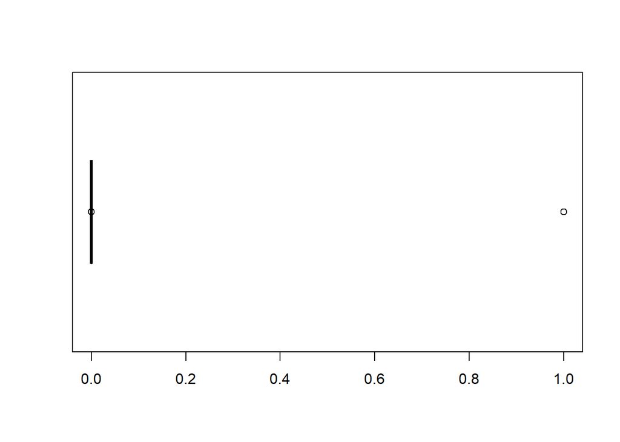

```
## $stats
##              [,1]
## [1,] 4.199720e-05
## [2,] 7.582828e-05
## [3,] 8.749417e-05
## [4,] 9.916006e-05
## [5,] 1.166589e-04
##
## $n
## [1] 2744
##
## $conf
##              [,1]
## [1,] 8.679043e-05
## [2,] 8.819791e-05
```

[output cut: 46 more lines]

```r
(box <- boxplot(ramen_1h$Stars, horizontal = TRUE))
```

```r
box$stats
```

```
##              [,1]
## [1,] 4.199720e-05
## [2,] 7.582828e-05
## [3,] 8.749417e-05
## [4,] 9.916006e-05
## [5,] 1.166589e-04
```

```r
fivenum(ramen_1h$Stars)
```

```
## [1] 0.000000e+00 7.582828e-05 8.749417e-05 9.916006e-05 1.000000e+00
```

```r
#making a predictor!
(ramen_1h$Stars <- cut(ramen_1h$Stars,c(-1,9.916006e-05,1),labels = c(0,1), na.rm=TRUE))
```

```
##    [1] 1 0 1 0 0 1 1 0 1 1 0 0 1 0 0 0 0 0 0 0 1 0 0 0 0 0 0 0 0 0 0 0 0 0 0 1 0
##   [38] 0 1 0 1 0 1 0 1 1 0 1 0 0 0 1 0 0 1 0 0 0 0 1 0 0 1 1 0 0 0 0 0 0 0 1 0 0
##   [75] 1 0 0 1 1 1 0 0 0 0 1 0 0 1 0 1 0 0 0 1 1 0 0 0 0 1 0 0 0 0 0 1 1 1 0 0 0
##  [112] 0 1 0 0 1 0 0 0 0 0 0 1 0 1 1 0 0 0 0 0 1 1 0 1 0 1 0 0 1 1 1 0 0 0 1 0 0
##  [149] 1 1 0 0 1 1 1 1 0 1 0 0 0 0 0 1 1 1 1 0 0 0 0 0 0 0 1 0 0 0 0 1 1 0 1 1 0
##  [186] 0 1 0 0 0 1 1 1 0 0 0 1 1 0 1 1 0 0 1 0 1 0 1 0 0 1 1 0 1 0 1 1 0 0 1 1 0
##  [223] 1 0 1 1 1 1 1 0 0 1 0 1 1 0 1 1 1 0 0 0 0 0 0 0 0 0 1 1 0 0 1 0 0 0 0 1 0
##  [260] 0 0 1 0 0 0 1 1 0 0 0 1 1 0 1 0 0 0 1 0 0 0 0 0 0 0 0 1 1 1 0 0 0 1 0 1 1
##  [297] 1 0 1 0 0 1 0 1 0 0 1 1 1 1 1 1 0 0 0 0 0 1 0 1 0 0 1 0 0 0 1 0 1 1 0 0 1
##  [334] 1 0 0 0 0 0 0 1 0 0 1 1 0 1 1 0 0 0 0 0 0 0 1 1 0 0 0 0 0 1 0 0 0 1 0 0 1
##  [371] 1 0 1 1 1 0 0 1 0 0 0 1 1 0 0 0 1 0 0 0 1 0 0 1 0 0 0 0 0 0 0 0 1 0 0 0 0
##  [408] 0 0 0 0 0 1 0 0 0 0 0 1 0 0 0 0 1 1 0 1 0 0 1 0 1 0 0 0 1 0 0 0 0 0 0 0 1
##  [445] 0 1 0 0 0 0 0 0 0 0 1 1 0 1 0 0 0 0 0 0 1 1 0 0 1 1 0 0 0 0 0 0 1 0 0 1 0
##  [482] 0 0 0 0 1 0 1 0 0 0 0 1 0 0 1 0 0 0 1 1 0 0 0 0 0 0 0 0 0 1 0 0 1 0 1 0 0
##  [519] 0 1 0 0 0 0 0 1 1 1 0 0 1 0 1 0 0 0 0 0 1 0 0 1 0 0 0 0 0 1 0 0 1 0 1 0 0
```

[output cut: 61 more lines]

```r
(prevalence <- 1 - table(ramen_1h$Stars)[[2]]/length(ramen_1h$Stars))
```

```
## [1] 0.7656706
```

## Phase 3

### Initial Model Building: Decision Tree Style

```r
#drop cols 1, 6, 15
ramen_1h <- ramen_1h[, -c(1,6, 15)]

#data partitioning
part_index_1 <- caret::createDataPartition(ramen_1h$Stars,
                                           times=1,
                                           p = 0.70,
                                           groups=1,
                                           list=FALSE
                                           )
#help(createDataPartition)
train <- ramen_1h[part_index_1,]
tune_and_test <- ramen_1h[-part_index_1, ]

tune_and_test_index <- createDataPartition(tune_and_test$Stars,
                                           p = .5,
                                           list = FALSE,
                                           times = 1)

tune <- tune_and_test[tune_and_test_index, ]
test <- tune_and_test[-tune_and_test_index, ]

dim(train)
```

```
## [1] 1922   13
```

```r
dim(tune)
```

```
## [1] 411  13
```

```r
dim(test)
```

```
## [1] 411  13
```

#### Cross Validation

```r
fitControl <- trainControl(method = "repeatedcv",
                          number = 10,
                          repeats = 5,
                          returnResamp="all")

# number - number of folds
# repeats - number of times the CV is repeated, here it's 5 take the average of
# those 5 repeats

# Choose the features and classes
```

#### Training & Evaluation

```r
features <- train[,-c(13)]
#target <- train[, "user rating score"]
target <- data.frame(`user rating score` = train[,13])



str(target)
```

```
## 'data.frame':    1922 obs. of  1 variable:
##  $ Stars: Factor w/ 2 levels "0","1": 1 2 1 1 2 2 1 2 2 1 ...
```

```r
set.seed(1984)
ramen_mdl <- train(x=features,
                y=target[,"Stars"],
                trControl=fitControl,
                method="C5.0",
                verbose=TRUE
                )

ramen_mdl
```

```
## C5.0
##
## 1922 samples
##   12 predictor
##    2 classes: '0', '1'
##
## No pre-processing
## Resampling: Cross-Validated (10 fold, repeated 5 times)
## Summary of sample sizes: 1730, 1730, 1730, 1729, 1729, 1730, ...
## Resampling results across tuning parameters:
##
##   model  winnow  trials  Accuracy   Kappa
##   rules  FALSE    1      0.7653497  0
##   rules  FALSE   10      0.7653497  0
##   rules  FALSE   20      0.7653497  0
##   rules   TRUE    1      0.7653497  0
##   rules   TRUE   10      0.7653497  0
##   rules   TRUE   20      0.7653497  0
##   tree   FALSE    1      0.7653497  0
##   tree   FALSE   10      0.7653497  0
##   tree   FALSE   20      0.7653497  0
##   tree    TRUE    1      0.7653497  0
##   tree    TRUE   10      0.7653497  0
##   tree    TRUE   20      0.7653497  0
##
## Accuracy was used to select the optimal model using the largest value.
## The final values used for the model were trials = 1, model = rules and winnow
##  = TRUE.
```

Evaluate the model built by the training data (keep in mind the prevalance): The prevalence was found to be 0.7660, and the accuracy of the model built by the training data was found to be 0.7653. This means that the model is actually slightly worse in predicting than just using the prevalence would be, so we should change some things in our process to improve the model (this may include adding more features among other things).

### Tune and Evaluation

```r
ramen_predict = predict(ramen_mdl,tune,type= "raw")

confusionMatrix(as.factor(ramen_predict),
                as.factor(tune$Stars),
                dnn=c("Prediction", "Actual"),
                mode = "sens_spec")
```

```
## Confusion Matrix and Statistics
##
##           Actual
## Prediction   0   1
##          0 315  96
##          1   0   0
##
##                Accuracy : 0.7664
##                  95% CI : (0.7225, 0.8065)
##     No Information Rate : 0.7664
##     P-Value [Acc > NIR] : 0.5273
##
##                   Kappa : 0
##
##  Mcnemar's Test P-Value : <2e-16
##
##             Sensitivity : 1.0000
##             Specificity : 0.0000
##          Pos Pred Value : 0.7664
##          Neg Pred Value :    NaN
##              Prevalence : 0.7664
##          Detection Rate : 0.7664
##    Detection Prevalence : 1.0000
##       Balanced Accuracy : 0.5000
##
##        'Positive' Class : 0
##
```

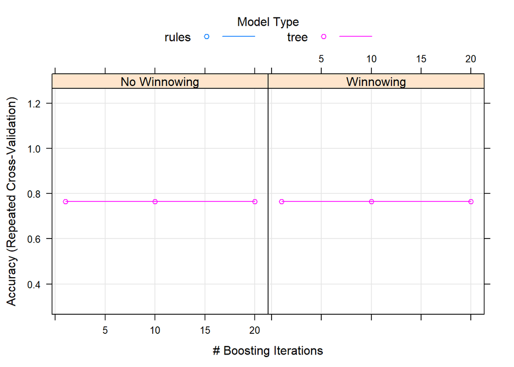

```r
#varImp(ramen_mdl)

plot(ramen_mdl)
```

```r
grid <- expand.grid(.winnow = c(TRUE,FALSE),
                    .trials=c(20,30,40),
                    .model=c("tree","rules"))
set.seed(1984)
ramen_mdl_tune <- train(x=features,
                y=target$Stars,
                tuneGrid=grid,
                trControl=fitControl,
                method="C5.0",
                verbose=TRUE)

ramen_mdl_tune
```

```
## C5.0
##
## 1922 samples
##   12 predictor
##    2 classes: '0', '1'
##
## No pre-processing
## Resampling: Cross-Validated (10 fold, repeated 5 times)
## Summary of sample sizes: 1730, 1730, 1730, 1729, 1729, 1730, ...
## Resampling results across tuning parameters:
##
##   model  winnow  trials  Accuracy   Kappa
##   rules  FALSE   20      0.7653497  0
##   rules  FALSE   30      0.7653497  0
##   rules  FALSE   40      0.7653497  0
##   rules   TRUE   20      0.7653497  0
##   rules   TRUE   30      0.7653497  0
##   rules   TRUE   40      0.7653497  0
##   tree   FALSE   20      0.7653497  0
##   tree   FALSE   30      0.7653497  0
##   tree   FALSE   40      0.7653497  0
##   tree    TRUE   20      0.7653497  0
##   tree    TRUE   30      0.7653497  0
##   tree    TRUE   40      0.7653497  0
##
## Accuracy was used to select the optimal model using the largest value.
## The final values used for the model were trials = 20, model = rules and
##  winnow = TRUE.
```

```r
ramen_mdl
```

```
## C5.0
##
## 1922 samples
##   12 predictor
##    2 classes: '0', '1'
##
## No pre-processing
## Resampling: Cross-Validated (10 fold, repeated 5 times)
## Summary of sample sizes: 1730, 1730, 1730, 1729, 1729, 1730, ...
## Resampling results across tuning parameters:
##
##   model  winnow  trials  Accuracy   Kappa
##   rules  FALSE    1      0.7653497  0
##   rules  FALSE   10      0.7653497  0
##   rules  FALSE   20      0.7653497  0
##   rules   TRUE    1      0.7653497  0
##   rules   TRUE   10      0.7653497  0
##   rules   TRUE   20      0.7653497  0
##   tree   FALSE    1      0.7653497  0
##   tree   FALSE   10      0.7653497  0
##   tree   FALSE   20      0.7653497  0
##   tree    TRUE    1      0.7653497  0
##   tree    TRUE   10      0.7653497  0
##   tree    TRUE   20      0.7653497  0
##
## Accuracy was used to select the optimal model using the largest value.
## The final values used for the model were trials = 1, model = rules and winnow
##  = TRUE.
```

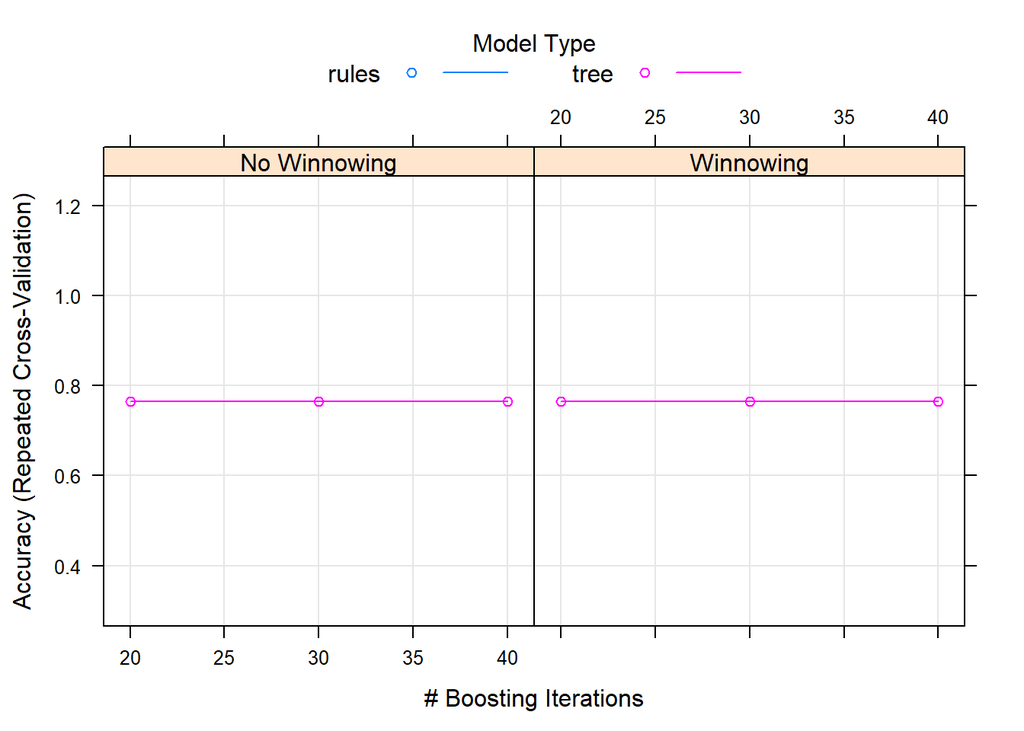

```r
plot(ramen_mdl_tune)
```

```r
# Want to evaluation again with the tune data using the new model

ramen_predict_tune = predict(ramen_mdl_tune,tune,type= "raw")

confusionMatrix(as.factor(ramen_predict_tune),
                as.factor(tune$Stars),
                dnn=c("Prediction", "Actual"),
                mode = "sens_spec")
```

```
## Confusion Matrix and Statistics
##
##           Actual
## Prediction   0   1
##          0 315  96
##          1   0   0
##
##                Accuracy : 0.7664
##                  95% CI : (0.7225, 0.8065)
##     No Information Rate : 0.7664
##     P-Value [Acc > NIR] : 0.5273
##
##                   Kappa : 0
##
##  Mcnemar's Test P-Value : <2e-16
##
##             Sensitivity : 1.0000
##             Specificity : 0.0000
##          Pos Pred Value : 0.7664
##          Neg Pred Value :    NaN
##              Prevalence : 0.7664
##          Detection Rate : 0.7664
##    Detection Prevalence : 1.0000
##       Balanced Accuracy : 0.5000
##
##        'Positive' Class : 0
##
```

Explore the variable importance measures, what do the results tell you? I got an error when creating my ramen_mdl that said “there were missing values in resampled performance measures. Stackoverflow says that this error happens when”the model doesn’t converge in some cross-validation folds the predictions get zero variance. As a result, the metrics like RMSE or Rsquared can’t be calculated so they become NAs. Sometimes there are parameters you can tune for better convergence." This error led to an error in parsing the model output when I tried to run VarImp, so I’m sure if some features could be tuned then I could get the VarImp, and my interpretation would be similar to those above, where 100 means the variable was helpful in reducing error and would thus be found in 100% of the models created (as the number decreases, it is found in fewer models).

### Test

```r
ramen_predict_test = predict(ramen_mdl_tune,test,type= "raw")

confusionMatrix(as.factor(ramen_predict_test),
                as.factor(test$Stars),
                dnn=c("Prediction", "Actual"),
                mode = "sens_spec")
```

```
## Confusion Matrix and Statistics
##
##           Actual
## Prediction   0   1
##          0 315  96
##          1   0   0
##
##                Accuracy : 0.7664
##                  95% CI : (0.7225, 0.8065)
##     No Information Rate : 0.7664
##     P-Value [Acc > NIR] : 0.5273
##
##                   Kappa : 0
##
##  Mcnemar's Test P-Value : <2e-16
##
##             Sensitivity : 1.0000
##             Specificity : 0.0000
##          Pos Pred Value : 0.7664
##          Neg Pred Value :    NaN
##              Prevalence : 0.7664
##          Detection Rate : 0.7664
##    Detection Prevalence : 1.0000
##       Balanced Accuracy : 0.5000
##
##        'Positive' Class : 0
##
```

Evaluate using the confusion matrix function - did the model perform better or worse than the training version? The model performed the same as the training version as the accuracy for both was 0.766.

## Summary

Write a summary of your findings. What do you know now that you didn’t when you started? What items are you concerned about

I found that the ramen model was not very useful in predicting the respective success over the next year because the prevalence and accuracy were approximately equal for the training model. That being said, the data I chose to train my model with does not serve its purpose properly. I either need to change my question and see if the dataset better answers that new question, or I need to change my dataset to see if the new dataset will better answer my question.

# Overall Summary

Having completed this lab, I certainly know a lot more than when I started. After attending multiple office hour sessions, I finally understand what prevalence is and how to interpret the models that I created in the above code. However, I am still a little concerned about the process of training, tuning, and testing and how that all works together. I am also slightly confused on the specifics of how to fix/improve models, considering that two of mine were average at best.